# 連續資料相關性分析 (The Correlation of Continuous Data)

JianKai Wang (https://sophia.ddns.net/)

2018年4月12日

## Pearson’s Correlation

Pearson’s Correlation 是對連續並符合常態假設(或符合中央極限定理)的資料進行相關分析的方法。若對於一群的資料，其定義為

$$\rho_{X,Y} = \frac{cov(X,Y)}{\sigma_X\sigma_Y} = \frac{E[(X - \mu_X)(Y - \mu_Y)]}{\sigma_X\sigma_Y}$$

其中 $cov$ 為共變異數 (covariance)， $\sigma_X$ 為 $x$ 的標準差，$\mu_X$ 為 x 的平均值, $E$ 為期望值。

若對於單一樣本 (sample)，其定義為

$$r = \frac{\Sigma_{i=1}^{n}(X_i-\bar{X})(Y_i-\bar{Y})}{\sqrt{\Sigma_{i=1}^{n}(X_i-\bar{X})^2}\sqrt{\Sigma_{i=1}^{n}(Y_i-\bar{Y})^2}}$$
其上定義亦可表示為

$$r = \frac{1}{n-1}\Sigma_{i=1}^{n}(\frac{X_i-\bar{X}}{S_X})(\frac{Y_i-\bar{Y}}{S_Y})\\
\bar{X} = \frac{1}{n}\Sigma_{i=1}^{n}X_i \\
\ S_X = \sqrt{\frac{1}{n-1}\Sigma_{i=1}^{n}(X_i-\bar{X})^{2}}$$

$\bar{X}$ 為 x 的算術平均，$S_X$ 為 x 的標準差。

## Spearman’s Rank Correlation

Spearman’s Rank Correlation 是對**連續但不符合常態假設(或不符合中央極限定理)的資料進行相關分析**的方法。Spearman’s Rank Correlation 被定義為**等級變量間**的 Pearson’s Correlation，Spearman 會先將資料透過排序 (Rank) ，並將排序後的等級進行 Pearson’s Correlation。

舉例而言，會先將資料進行排序處理，

| 變量 $x_i$ | 降序位置 | 等級 $rg_{x_i}$ |
| --- | --- | --- |
| 0.8 | 5 | 5 |
| 1.0 | 4 | $\frac{3+4}{2} = 3.5$ |
| 1.0 | 3 | $\frac{3+4}{2} = 3.5$ |
| 2.5 | 2 | 2 |
| 3.0 | 1 | 1 |

故 Spearman’s Rank Correlation 如下定義

$$r_s = \rho_{rg_x, rg_y} = \frac{cov(rg_x, rg_y)}{\rho_{rg_x}\rho_{rg_y}}$$

其中 $\rho$ 即是 Pearson’s Correlation 定義，但應用於排序後的值(rank variables)。$cov(rg_x, rg_y)$ 為排序值的共變異係數。$\rho_{rg_x}$ 與 $\rho_{rg_y}$ 為排序值的標準差。

$d_i = rg(x_i) - rg(y_i)$ 為兩個變數之排序值的差。$n$ 表示有幾個變數。

相關性的值介於 -1 至 1 之間，其中 1 為完全正相關，-1 為完全負相關，0 為無相關。

## R 實作

### 相關性係數

於 R 的基礎套件 **stats** 中已有內建函式 **cor** 可以計算相關性。其中可透過 **method** 來轉換 Pearson 或 Spearman 的相關性計算。

```r
# the prototype of correlation
cor(x, y = NULL, use = "everything",
    method = c("pearson", "kendall", "spearman"))
```

```r
set.seed(123)

# 準備資料
data1 <- c(
  c(1:100) + rnorm(100, mean = 10, sd = 5) - rnorm(100, mean = 5, sd = 5),
  c(140:150) + rnorm(10, mean = 5, sd = 5)
)
data2 <- c(
  c(1:100) + rnorm(100, mean = 20, sd = 10) - rnorm(100, mean = 10, sd = 10),
  c(80:90) + rnorm(10, mean = 5, sd = 5)
)
```

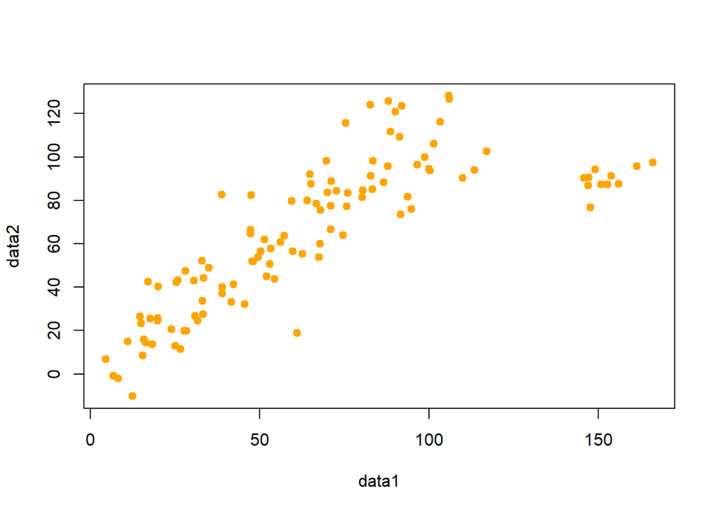

```r
# 繪出資料分布
plot(x=data1, y=data2, col="orange", pch=19)
```

```r
# Pearson's Correlation
pearsonRes <- cor(data1, data2, use = "everything", method = "pearson")
pearsonRes
```

```
## [1] 0.7842095
```

```r
# Spearman's Rank Correlation
spearmanRes <- cor(data1, data2, use = "everything", method = "spearman")
spearmanRes
```

```
## [1] 0.8814584
```

由上可以看出 Pearson’s 與 Spearman’s 相關性計算結果有明顯差異。

### 相關性檢驗

於 R 的基礎套件 **stats** 中已有內建函式 **cor.test** 可以對相關性進行檢定。其中可透過 **method** 來轉換 Pearson 或 Spearman 的相關性計算。

```r
# the prototype of cor.test
# alternative: 檢定方式為雙尾，單尾(less, greater)等
cor.test(x, y,
         alternative = c("two.sided", "less", "greater"),
         method = c("pearson", "kendall", "spearman"),
         exact = NULL, conf.level = 0.95, continuity = FALSE, ...)
```

- Pearson’s Correlation

```r
# 相關性檢定
pearsonTest <- cor.test(data1, data2, alternative = "two.sided", method = "pearson")

# 透過屬性 estimate 來取得相關性
pearsonTest$estimate
```

```
##       cor
## 0.7842095
```

```r
# 透過屬性 p.value 來取得檢驗結果
pearsonTest$p.value
```

```
## [1] 2.47712e-24
```

- Spearman’s Rank Correlation

```r
# 相關性檢定
spearmanTest <- cor.test(data1, data2, alternative = "two.sided", method = "spearman")

# 透過屬性 estimate 來取得相關性
spearmanTest$estimate
```

```
##       rho
## 0.8814584
```

```r
# 透過屬性 p.value 來取得檢驗結果
spearmanTest$p.value
```

```
## [1] 0
```